# Risk Factor Analysis

## Outcome Variable

**Outcome Variable:** stunted

## Predictor Variables

**Intervention Variable:** hdlvry

**Adjustment Set:**

unadjusted

## Stratifying Variables

The analysis was stratified on these variable(s):

- agecat
- studyid

The following strata were considered:

- agecat: 12 months, studyid: ki1000108-CMC-V-BCS-2002
- agecat: 12 months, studyid: ki1000108-IRC
- agecat: 12 months, studyid: ki1000109-EE
- agecat: 12 months, studyid: ki1000304b-SAS-FoodSuppl
- agecat: 12 months, studyid: ki1017093b-PROVIDE
- agecat: 12 months, studyid: ki1017093c-NIH-Crypto
- agecat: 12 months, studyid: ki1066203-TanzaniaChild2
- agecat: 12 months, studyid: ki1113344-GMS-Nepal
- agecat: 12 months, studyid: ki1135781-COHORTS
- agecat: 18 months, studyid: ki1000108-CMC-V-BCS-2002
- agecat: 18 months, studyid: ki1000108-IRC
- agecat: 18 months, studyid: ki1000109-EE
- agecat: 18 months, studyid: ki1000304b-SAS-FoodSuppl
- agecat: 18 months, studyid: ki1017093b-PROVIDE
- agecat: 18 months, studyid: ki1017093c-NIH-Crypto
- agecat: 18 months, studyid: ki1066203-TanzaniaChild2
- agecat: 18 months, studyid: ki1113344-GMS-Nepal
- agecat: 24 months, studyid: ki1000108-CMC-V-BCS-2002
- agecat: 24 months, studyid: ki1000108-IRC
- agecat: 24 months, studyid: ki1017093b-PROVIDE
- agecat: 24 months, studyid: ki1017093c-NIH-Crypto
- agecat: 24 months, studyid: ki1066203-TanzaniaChild2
- agecat: 24 months, studyid: ki1113344-GMS-Nepal
- agecat: 24 months, studyid: ki1135781-COHORTS
- agecat: 3 months, studyid: ki1000108-CMC-V-BCS-2002
- agecat: 3 months, studyid: ki1000108-IRC
- agecat: 3 months, studyid: ki1000109-EE
- agecat: 3 months, studyid: ki1000304b-SAS-FoodSuppl
- agecat: 3 months, studyid: ki1017093b-PROVIDE
- agecat: 3 months, studyid: ki1017093c-NIH-Crypto
- agecat: 3 months, studyid: ki1066203-TanzaniaChild2
- agecat: 3 months, studyid: ki1113344-GMS-Nepal
- agecat: 3 months, studyid: ki1135781-COHORTS
- agecat: 6 months, studyid: ki1000108-CMC-V-BCS-2002
- agecat: 6 months, studyid: ki1000108-IRC
- agecat: 6 months, studyid: ki1000109-EE
- agecat: 6 months, studyid: ki1000304b-SAS-FoodSuppl
- agecat: 6 months, studyid: ki1017093b-PROVIDE
- agecat: 6 months, studyid: ki1017093c-NIH-Crypto
- agecat: 6 months, studyid: ki1066203-TanzaniaChild2
- agecat: 6 months, studyid: ki1113344-GMS-Nepal
- agecat: 6 months, studyid: ki1135781-COHORTS
- agecat: 9 months, studyid: ki1000108-CMC-V-BCS-2002
- agecat: 9 months, studyid: ki1000108-IRC
- agecat: 9 months, studyid: ki1000109-EE
- agecat: 9 months, studyid: ki1000304b-SAS-FoodSuppl
- agecat: 9 months, studyid: ki1017093b-PROVIDE
- agecat: 9 months, studyid: ki1017093c-NIH-Crypto
- agecat: 9 months, studyid: ki1066203-TanzaniaChild2
- agecat: 9 months, studyid: ki1113344-GMS-Nepal
- agecat: 9 months, studyid: ki1135781-COHORTS
- agecat: Birth, studyid: ki1000108-CMC-V-BCS-2002
- agecat: Birth, studyid: ki1000108-IRC
- agecat: Birth, studyid: ki1000109-EE
- agecat: Birth, studyid: ki1017093c-NIH-Crypto
- agecat: Birth, studyid: ki1135781-COHORTS

### Dropped Strata

Some strata were dropped due to rare outcomes:

- agecat: Birth, studyid: ki1000108-CMC-V-BCS-2002
- agecat: Birth, studyid: ki1000108-IRC
- agecat: Birth, studyid: ki1000109-EE
- agecat: Birth, studyid: ki1017093c-NIH-Crypto
- agecat: 3 months, studyid: ki1000108-CMC-V-BCS-2002
- agecat: 3 months, studyid: ki1000108-IRC
- agecat: 3 months, studyid: ki1066203-TanzaniaChild2
- agecat: 6 months, studyid: ki1000108-CMC-V-BCS-2002
- agecat: 6 months, studyid: ki1000108-IRC
- agecat: 6 months, studyid: ki1017093b-PROVIDE
- agecat: 6 months, studyid: ki1066203-TanzaniaChild2
- agecat: 9 months, studyid: ki1000108-CMC-V-BCS-2002
- agecat: 9 months, studyid: ki1000108-IRC
- agecat: 9 months, studyid: ki1066203-TanzaniaChild2
- agecat: 12 months, studyid: ki1000108-CMC-V-BCS-2002
- agecat: 12 months, studyid: ki1000108-IRC
- agecat: 12 months, studyid: ki1066203-TanzaniaChild2
- agecat: 18 months, studyid: ki1000108-CMC-V-BCS-2002
- agecat: 18 months, studyid: ki1000108-IRC
- agecat: 18 months, studyid: ki1000304b-SAS-FoodSuppl
- agecat: 18 months, studyid: ki1066203-TanzaniaChild2
- agecat: 24 months, studyid: ki1000108-CMC-V-BCS-2002
- agecat: 24 months, studyid: ki1000108-IRC
- agecat: 24 months, studyid: ki1066203-TanzaniaChild2

## Methods Detail

We’re interested in the causal parameters $E[Y_a]$ for all values of $a \in \mathcal{A}$. These parameters represent the mean outcome if, possibly contrary to fact, we intervened to set all units to have $A=a$. Under the randomization and positivity assumptions, these are identified by the statistical parameters $\psi_a=E_W[E_{Y|A,W}(Y|A=a,W)]$. In addition, we’re interested in the mean of $Y$, $E[Y]$ under no intervention (the observed mean). We will estimate these parameters by using SuperLearner to fit the relevant likelihood factors – $E_{Y|A,W}(Y|A=a,W)$ and $p(A=a|W)$, and then updating our likelihood fit using a joint TMLE.

For unadjusted analyses ($W=\{\}$), initial likelihoods were estimated using Lrnr_glm to estimate the simple $E(Y|A)$ and Lrnr_mean to estimate $p(A)$. For adjusted analyses, a small library containing Lrnr_glmnet, Lrnr_xgboost, and Lrnr_mean was used.

Having estimated these parameters, we will then use the delta method to estimate relative risks and attributable risks relative to a prespecified baseline level of $A$.

# Results Detail

## Results Plots

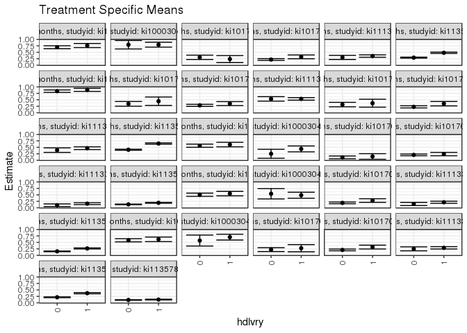

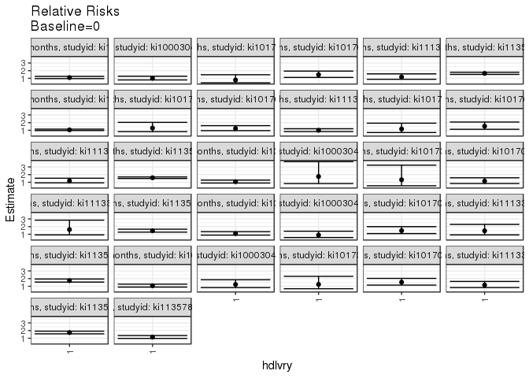

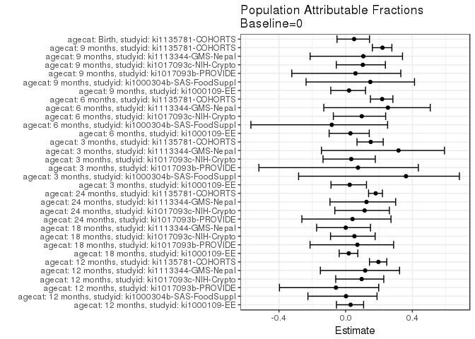

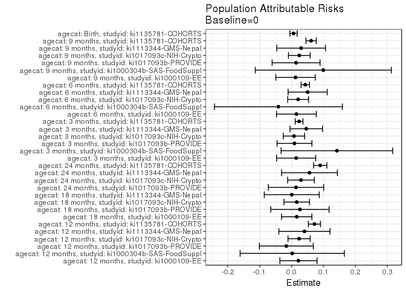

## Data Summary

| agecat | studyid | A | n | nA | nAY0 | nAY1 |
| --- | --- | --- | --- | --- | --- | --- |
| Birth | ki1000108-CMC-V-BCS-2002 | 0 | 90 | 90 | 74 | 16 |
| Birth | ki1000108-CMC-V-BCS-2002 | 1 | 90 | 0 | 0 | 0 |
| Birth | ki1000108-IRC | 0 | 388 | 381 | 337 | 44 |
| Birth | ki1000108-IRC | 1 | 388 | 7 | 6 | 1 |
| Birth | ki1000109-EE | 0 | 2 | 2 | 1 | 1 |
| Birth | ki1000109-EE | 1 | 2 | 0 | 0 | 0 |
| Birth | ki1000304b-SAS-FoodSuppl | 0 | 0 | 0 | 0 | 0 |
| Birth | ki1000304b-SAS-FoodSuppl | 1 | 0 | 0 | 0 | 0 |
| Birth | ki1017093b-PROVIDE | 0 | 0 | 0 | 0 | 0 |
| Birth | ki1017093b-PROVIDE | 1 | 0 | 0 | 0 | 0 |
| Birth | ki1017093c-NIH-Crypto | 0 | 27 | 22 | 18 | 4 |
| Birth | ki1017093c-NIH-Crypto | 1 | 27 | 5 | 4 | 1 |
| Birth | ki1066203-TanzaniaChild2 | 0 | 0 | 0 | 0 | 0 |
| Birth | ki1066203-TanzaniaChild2 | 1 | 0 | 0 | 0 | 0 |
| Birth | ki1113344-GMS-Nepal | 0 | 0 | 0 | 0 | 0 |
| Birth | ki1113344-GMS-Nepal | 1 | 0 | 0 | 0 | 0 |
| Birth | ki1135781-COHORTS | 0 | 4694 | 2938 | 2613 | 325 |
| Birth | ki1135781-COHORTS | 1 | 4694 | 1756 | 1534 | 222 |
| 3 months | ki1000108-CMC-V-BCS-2002 | 0 | 359 | 352 | 263 | 89 |
| 3 months | ki1000108-CMC-V-BCS-2002 | 1 | 359 | 7 | 7 | 0 |
| 3 months | ki1000108-IRC | 0 | 407 | 399 | 310 | 89 |
| 3 months | ki1000108-IRC | 1 | 407 | 8 | 6 | 2 |
| 3 months | ki1000109-EE | 0 | 374 | 252 | 110 | 142 |
| 3 months | ki1000109-EE | 1 | 374 | 122 | 48 | 74 |
| 3 months | ki1000304b-SAS-FoodSuppl | 0 | 97 | 24 | 18 | 6 |
| 3 months | ki1000304b-SAS-FoodSuppl | 1 | 97 | 73 | 41 | 32 |
| 3 months | ki1017093b-PROVIDE | 0 | 168 | 127 | 113 | 14 |
| 3 months | ki1017093b-PROVIDE | 1 | 168 | 41 | 35 | 6 |
| 3 months | ki1017093c-NIH-Crypto | 0 | 728 | 565 | 448 | 117 |
| 3 months | ki1017093c-NIH-Crypto | 1 | 728 | 163 | 124 | 39 |

[output cut: 96 more lines]

## Results Table

### Parameter: TSM

| agecat | studyid | intervention_level | baseline_level | estimate | ci_lower | ci_upper |
| --- | --- | --- | --- | --- | --- | --- |
| Birth | ki1135781-COHORTS | 0 | NA | 0.1106195 | 0.0992765 | 0.1219625 |
| Birth | ki1135781-COHORTS | 1 | NA | 0.1264237 | 0.1108785 | 0.1419689 |
| 3 months | ki1000109-EE | 0 | NA | 0.5634921 | 0.5021767 | 0.6248074 |
| 3 months | ki1000109-EE | 1 | NA | 0.6065574 | 0.5197561 | 0.6933587 |
| 3 months | ki1000304b-SAS-FoodSuppl | 0 | NA | 0.2500000 | 0.0758621 | 0.4241379 |
| 3 months | ki1000304b-SAS-FoodSuppl | 1 | NA | 0.4383562 | 0.3239417 | 0.5527706 |
| 3 months | ki1017093b-PROVIDE | 0 | NA | 0.1102362 | 0.0556048 | 0.1648676 |
| 3 months | ki1017093b-PROVIDE | 1 | NA | 0.1463415 | 0.0378293 | 0.2548536 |
| 3 months | ki1017093c-NIH-Crypto | 0 | NA | 0.2070796 | 0.1736443 | 0.2405150 |
| 3 months | ki1017093c-NIH-Crypto | 1 | NA | 0.2392638 | 0.1737235 | 0.3048041 |
| 3 months | ki1113344-GMS-Nepal | 0 | NA | 0.0984849 | 0.0476058 | 0.1493639 |
| 3 months | ki1113344-GMS-Nepal | 1 | NA | 0.1592040 | 0.1234055 | 0.1950024 |
| 3 months | ki1135781-COHORTS | 0 | NA | 0.1314554 | 0.1193264 | 0.1435844 |
| 3 months | ki1135781-COHORTS | 1 | NA | 0.1918542 | 0.1739866 | 0.2097219 |
| 6 months | ki1000109-EE | 0 | NA | 0.5040323 | 0.4417211 | 0.5663434 |
| 6 months | ki1000109-EE | 1 | NA | 0.5491803 | 0.4607676 | 0.6375931 |
| 6 months | ki1000304b-SAS-FoodSuppl | 0 | NA | 0.5416667 | 0.3412780 | 0.7420553 |
| 6 months | ki1000304b-SAS-FoodSuppl | 1 | NA | 0.4861111 | 0.3700577 | 0.6021646 |
| 6 months | ki1017093c-NIH-Crypto | 0 | NA | 0.1895307 | 0.1568715 | 0.2221899 |
| 6 months | ki1017093c-NIH-Crypto | 1 | NA | 0.2795031 | 0.2101368 | 0.3488694 |
| 6 months | ki1113344-GMS-Nepal | 0 | NA | 0.1472868 | 0.0860731 | 0.2085006 |
| 6 months | ki1113344-GMS-Nepal | 1 | NA | 0.2135678 | 0.1732667 | 0.2538690 |
| 6 months | ki1135781-COHORTS | 0 | NA | 0.1527586 | 0.1396637 | 0.1658535 |
| 6 months | ki1135781-COHORTS | 1 | NA | 0.2645914 | 0.2442055 | 0.2849774 |
| 9 months | ki1000109-EE | 0 | NA | 0.5813008 | 0.5195661 | 0.6430355 |
| 9 months | ki1000109-EE | 1 | NA | 0.6186441 | 0.5308854 | 0.7064028 |
| 9 months | ki1000304b-SAS-FoodSuppl | 0 | NA | 0.5714286 | 0.3585162 | 0.7843409 |
| 9 months | ki1000304b-SAS-FoodSuppl | 1 | NA | 0.7031250 | 0.5905269 | 0.8157231 |
| 9 months | ki1017093b-PROVIDE | 0 | NA | 0.2203390 | 0.1453177 | 0.2953602 |
| 9 months | ki1017093b-PROVIDE | 1 | NA | 0.2750000 | 0.1361864 | 0.4138136 |
| 9 months | ki1017093c-NIH-Crypto | 0 | NA | 0.2083333 | 0.1744304 | 0.2422362 |
| 9 months | ki1017093c-NIH-Crypto | 1 | NA | 0.3181818 | 0.2445666 | 0.3917970 |
| 9 months | ki1113344-GMS-Nepal | 0 | NA | 0.2500000 | 0.1737113 | 0.3262887 |
| 9 months | ki1113344-GMS-Nepal | 1 | NA | 0.2890026 | 0.2440280 | 0.3339771 |
| 9 months | ki1135781-COHORTS | 0 | NA | 0.2147678 | 0.1987290 | 0.2308065 |
| 9 months | ki1135781-COHORTS | 1 | NA | 0.3731723 | 0.3492686 | 0.3970760 |
| 12 months | ki1000109-EE | 0 | NA | 0.6942149 | 0.6360838 | 0.7523459 |
| 12 months | ki1000109-EE | 1 | NA | 0.7610619 | 0.6823258 | 0.8397981 |
| 12 months | ki1000304b-SAS-FoodSuppl | 0 | NA | 0.7916667 | 0.6282989 | 0.9550344 |
| 12 months | ki1000304b-SAS-FoodSuppl | 1 | NA | 0.7941176 | 0.6974861 | 0.8907492 |
| 12 months | ki1017093b-PROVIDE | 0 | NA | 0.3043478 | 0.2199747 | 0.3887210 |
| 12 months | ki1017093b-PROVIDE | 1 | NA | 0.2368421 | 0.1012243 | 0.3724600 |
| 12 months | ki1017093c-NIH-Crypto | 0 | NA | 0.2189781 | 0.1843286 | 0.2536276 |
| 12 months | ki1017093c-NIH-Crypto | 1 | NA | 0.3227848 | 0.2498311 | 0.3957385 |
| 12 months | ki1113344-GMS-Nepal | 0 | NA | 0.3015873 | 0.2213747 | 0.3817999 |
| 12 months | ki1113344-GMS-Nepal | 1 | NA | 0.3544304 | 0.3072128 | 0.4016480 |
| 12 months | ki1135781-COHORTS | 0 | NA | 0.2918871 | 0.2731741 | 0.3106002 |
| 12 months | ki1135781-COHORTS | 1 | NA | 0.4807553 | 0.4543623 | 0.5071483 |
| 18 months | ki1000109-EE | 0 | NA | 0.8347458 | 0.7872920 | 0.8821995 |
| 18 months | ki1000109-EE | 1 | NA | 0.8839286 | 0.8245219 | 0.9433352 |
| 18 months | ki1017093b-PROVIDE | 0 | NA | 0.3428571 | 0.2517431 | 0.4339712 |
| 18 months | ki1017093b-PROVIDE | 1 | NA | 0.4444444 | 0.2815468 | 0.6073421 |
| 18 months | ki1017093c-NIH-Crypto | 0 | NA | 0.2854209 | 0.2452794 | 0.3255625 |
| 18 months | ki1017093c-NIH-Crypto | 1 | NA | 0.3537415 | 0.2763883 | 0.4310947 |
| 18 months | ki1113344-GMS-Nepal | 0 | NA | 0.5348837 | 0.4487272 | 0.6210403 |
| 18 months | ki1113344-GMS-Nepal | 1 | NA | 0.5352480 | 0.4852490 | 0.5852471 |
| 24 months | ki1017093b-PROVIDE | 0 | NA | 0.3153153 | 0.2285858 | 0.4020448 |
| 24 months | ki1017093b-PROVIDE | 1 | NA | 0.3684211 | 0.2145331 | 0.5223090 |
| 24 months | ki1017093c-NIH-Crypto | 0 | NA | 0.2276215 | 0.1860204 | 0.2692225 |
| 24 months | ki1017093c-NIH-Crypto | 1 | NA | 0.3495935 | 0.2652421 | 0.4339449 |
| 24 months | ki1113344-GMS-Nepal | 0 | NA | 0.3916667 | 0.3042384 | 0.4790950 |
| 24 months | ki1113344-GMS-Nepal | 1 | NA | 0.4668588 | 0.4143100 | 0.5194076 |
| 24 months | ki1135781-COHORTS | 0 | NA | 0.4070757 | 0.3866958 | 0.4274556 |
| 24 months | ki1135781-COHORTS | 1 | NA | 0.6470588 | 0.6213335 | 0.6727841 |

### Parameter: E(Y)

| agecat | studyid | intervention_level | baseline_level | estimate | ci_lower | ci_upper |
| --- | --- | --- | --- | --- | --- | --- |
| Birth | ki1135781-COHORTS | NA | NA | 0.1165317 | 0.1163129 | 0.1167505 |
| 3 months | ki1000109-EE | NA | NA | 0.5775401 | 0.5754912 | 0.5795890 |
| 3 months | ki1000304b-SAS-FoodSuppl | NA | NA | 0.3917526 | 0.3754938 | 0.4080113 |
| 3 months | ki1017093b-PROVIDE | NA | NA | 0.1190476 | 0.1166956 | 0.1213997 |
| 3 months | ki1017093c-NIH-Crypto | NA | NA | 0.2142857 | 0.2133105 | 0.2152610 |
| 3 months | ki1113344-GMS-Nepal | NA | NA | 0.1441948 | 0.1419711 | 0.1464184 |
| 3 months | ki1135781-COHORTS | NA | NA | 0.1547030 | 0.1538756 | 0.1555303 |
| 6 months | ki1000109-EE | NA | NA | 0.5189189 | 0.5167533 | 0.5210845 |
| 6 months | ki1000304b-SAS-FoodSuppl | NA | NA | 0.5000000 | 0.4951626 | 0.5048374 |
| 6 months | ki1017093c-NIH-Crypto | NA | NA | 0.2097902 | 0.2070336 | 0.2125468 |
| 6 months | ki1113344-GMS-Nepal | NA | NA | 0.1973435 | 0.1949081 | 0.1997789 |
| 6 months | ki1135781-COHORTS | NA | NA | 0.1955735 | 0.1940191 | 0.1971280 |
| 9 months | ki1000109-EE | NA | NA | 0.5934066 | 0.5916085 | 0.5952047 |
| 9 months | ki1000304b-SAS-FoodSuppl | NA | NA | 0.6705882 | 0.6584414 | 0.6827351 |
| 9 months | ki1017093b-PROVIDE | NA | NA | 0.2341772 | 0.2304594 | 0.2378950 |
| 9 months | ki1017093c-NIH-Crypto | NA | NA | 0.2322946 | 0.2289459 | 0.2356433 |
| 9 months | ki1113344-GMS-Nepal | NA | NA | 0.2796117 | 0.2781700 | 0.2810533 |
| 9 months | ki1135781-COHORTS | NA | NA | 0.2756598 | 0.2732986 | 0.2780211 |
| 12 months | ki1000109-EE | NA | NA | 0.7154930 | 0.7122492 | 0.7187367 |
| 12 months | ki1000304b-SAS-FoodSuppl | NA | NA | 0.7934783 | 0.7932571 | 0.7936994 |
| 12 months | ki1017093b-PROVIDE | NA | NA | 0.2875817 | 0.2829449 | 0.2922185 |
| 12 months | ki1017093c-NIH-Crypto | NA | NA | 0.2422096 | 0.2390159 | 0.2454033 |
| 12 months | ki1113344-GMS-Nepal | NA | NA | 0.3416507 | 0.3397058 | 0.3435955 |
| 12 months | ki1135781-COHORTS | NA | NA | 0.3632373 | 0.3602642 | 0.3662104 |
| 18 months | ki1000109-EE | NA | NA | 0.8505747 | 0.8481571 | 0.8529923 |
| 18 months | ki1017093b-PROVIDE | NA | NA | 0.3687943 | 0.3614568 | 0.3761319 |
| 18 months | ki1017093c-NIH-Crypto | NA | NA | 0.3012618 | 0.2990157 | 0.3035079 |
| 18 months | ki1113344-GMS-Nepal | NA | NA | 0.5351562 | 0.5351425 | 0.5351700 |
| 24 months | ki1017093b-PROVIDE | NA | NA | 0.3288591 | 0.3251298 | 0.3325883 |
| 24 months | ki1017093c-NIH-Crypto | NA | NA | 0.2568093 | 0.2523061 | 0.2613126 |
| 24 months | ki1113344-GMS-Nepal | NA | NA | 0.4475375 | 0.4445544 | 0.4505206 |
| 24 months | ki1135781-COHORTS | NA | NA | 0.4964878 | 0.4926752 | 0.5003003 |

### Parameter: RR

| agecat | studyid | intervention_level | baseline_level | estimate | ci_lower | ci_upper |
| --- | --- | --- | --- | --- | --- | --- |
| Birth | ki1135781-COHORTS | 1 | 0 | 1.1428702 | 0.9737860 | 1.341313 |
| 3 months | ki1000109-EE | 1 | 0 | 1.0764258 | 0.8993081 | 1.288427 |
| 3 months | ki1000304b-SAS-FoodSuppl | 1 | 0 | 1.7534247 | 0.8333705 | 3.689233 |
| 3 months | ki1017093b-PROVIDE | 1 | 0 | 1.3275261 | 0.5441396 | 3.238738 |
| 3 months | ki1017093c-NIH-Crypto | 1 | 0 | 1.1554192 | 0.8407120 | 1.587932 |
| 3 months | ki1113344-GMS-Nepal | 1 | 0 | 1.6165327 | 0.9202140 | 2.839750 |
| 3 months | ki1135781-COHORTS | 1 | 0 | 1.4594626 | 1.2801413 | 1.663903 |
| 6 months | ki1000109-EE | 1 | 0 | 1.0895738 | 0.8894126 | 1.334781 |
| 6 months | ki1000304b-SAS-FoodSuppl | 1 | 0 | 0.8974359 | 0.5778122 | 1.393863 |
| 6 months | ki1017093c-NIH-Crypto | 1 | 0 | 1.4747116 | 1.0901648 | 1.994904 |
| 6 months | ki1113344-GMS-Nepal | 1 | 0 | 1.4500132 | 0.9186313 | 2.288773 |
| 6 months | ki1135781-COHORTS | 1 | 0 | 1.7320884 | 1.5435253 | 1.943687 |
| 9 months | ki1000109-EE | 1 | 0 | 1.0642408 | 0.8914159 | 1.270573 |
| 9 months | ki1000304b-SAS-FoodSuppl | 1 | 0 | 1.2304687 | 0.8202408 | 1.845865 |
| 9 months | ki1017093b-PROVIDE | 1 | 0 | 1.2480769 | 0.6789079 | 2.294414 |
| 9 months | ki1017093c-NIH-Crypto | 1 | 0 | 1.5272727 | 1.1509894 | 2.026571 |
| 9 months | ki1113344-GMS-Nepal | 1 | 0 | 1.1560102 | 0.8207226 | 1.628272 |
| 9 months | ki1135781-COHORTS | 1 | 0 | 1.7375619 | 1.5747480 | 1.917209 |
| 12 months | ki1000109-EE | 1 | 0 | 1.0962916 | 0.9596718 | 1.252361 |
| 12 months | ki1000304b-SAS-FoodSuppl | 1 | 0 | 1.0030960 | 0.7894069 | 1.274630 |
| 12 months | ki1017093b-PROVIDE | 1 | 0 | 0.7781955 | 0.4119038 | 1.470217 |
| 12 months | ki1017093c-NIH-Crypto | 1 | 0 | 1.4740506 | 1.1186428 | 1.942376 |
| 12 months | ki1113344-GMS-Nepal | 1 | 0 | 1.1752165 | 0.8728295 | 1.582364 |
| 12 months | ki1135781-COHORTS | 1 | 0 | 1.6470588 | 1.5137453 | 1.792113 |
| 18 months | ki1000109-EE | 1 | 0 | 1.0589195 | 0.9696919 | 1.156357 |
| 18 months | ki1017093b-PROVIDE | 1 | 0 | 1.2962963 | 0.8243061 | 2.038544 |
| 18 months | ki1017093c-NIH-Crypto | 1 | 0 | 1.2393677 | 0.9556222 | 1.607363 |
| 18 months | ki1113344-GMS-Nepal | 1 | 0 | 1.0006811 | 0.8306713 | 1.205486 |
| 24 months | ki1017093b-PROVIDE | 1 | 0 | 1.1684211 | 0.7085940 | 1.926643 |
| 24 months | ki1017093c-NIH-Crypto | 1 | 0 | 1.5358546 | 1.1347332 | 2.078770 |
| 24 months | ki1113344-GMS-Nepal | 1 | 0 | 1.1919799 | 0.9283203 | 1.530523 |
| 24 months | ki1135781-COHORTS | 1 | 0 | 1.5895295 | 1.4910909 | 1.694467 |

### Parameter: PAR

| agecat | studyid | intervention_level | baseline_level | estimate | ci_lower | ci_upper |
| --- | --- | --- | --- | --- | --- | --- |
| Birth | ki1135781-COHORTS | 0 | NA | 0.0059123 | -0.0054328 | 0.0172574 |
| 3 months | ki1000109-EE | 0 | NA | 0.0140480 | -0.0473015 | 0.0753976 |
| 3 months | ki1000304b-SAS-FoodSuppl | 0 | NA | 0.1417526 | -0.0331427 | 0.3166479 |
| 3 months | ki1017093b-PROVIDE | 0 | NA | 0.0088114 | -0.0458706 | 0.0634934 |
| 3 months | ki1017093c-NIH-Crypto | 0 | NA | 0.0072061 | -0.0262435 | 0.0406556 |
| 3 months | ki1113344-GMS-Nepal | 0 | NA | 0.0457099 | -0.0052178 | 0.0966376 |
| 3 months | ki1135781-COHORTS | 0 | NA | 0.0232476 | 0.0110904 | 0.0354047 |
| 6 months | ki1000109-EE | 0 | NA | 0.0148867 | -0.0474621 | 0.0772354 |
| 6 months | ki1000304b-SAS-FoodSuppl | 0 | NA | -0.0416667 | -0.2421137 | 0.1587803 |
| 6 months | ki1017093c-NIH-Crypto | 0 | NA | 0.0202595 | -0.0125158 | 0.0530348 |
| 6 months | ki1113344-GMS-Nepal | 0 | NA | 0.0500566 | -0.0112056 | 0.1113188 |
| 6 months | ki1135781-COHORTS | 0 | NA | 0.0428149 | 0.0296281 | 0.0560017 |
| 9 months | ki1000109-EE | 0 | NA | 0.0121058 | -0.0496551 | 0.0738667 |
| 9 months | ki1000304b-SAS-FoodSuppl | 0 | NA | 0.0991597 | -0.1140989 | 0.3124182 |
| 9 months | ki1017093b-PROVIDE | 0 | NA | 0.0138382 | -0.0612751 | 0.0889516 |
| 9 months | ki1017093c-NIH-Crypto | 0 | NA | 0.0239613 | -0.0101066 | 0.0580292 |
| 9 months | ki1113344-GMS-Nepal | 0 | NA | 0.0296117 | -0.0466906 | 0.1059139 |
| 9 months | ki1135781-COHORTS | 0 | NA | 0.0608921 | 0.0446804 | 0.0771037 |
| 12 months | ki1000109-EE | 0 | NA | 0.0212781 | -0.0369434 | 0.0794996 |
| 12 months | ki1000304b-SAS-FoodSuppl | 0 | NA | 0.0018116 | -0.1615563 | 0.1651795 |
| 12 months | ki1017093b-PROVIDE | 0 | NA | -0.0167661 | -0.1012666 | 0.0677343 |
| 12 months | ki1017093c-NIH-Crypto | 0 | NA | 0.0232315 | -0.0115649 | 0.0580279 |
| 12 months | ki1113344-GMS-Nepal | 0 | NA | 0.0400634 | -0.0401728 | 0.1202995 |
| 12 months | ki1135781-COHORTS | 0 | NA | 0.0713502 | 0.0524024 | 0.0902980 |
| 18 months | ki1000109-EE | 0 | NA | 0.0158289 | -0.0316863 | 0.0633442 |
| 18 months | ki1017093b-PROVIDE | 0 | NA | 0.0259372 | -0.0654719 | 0.1173462 |
| 18 months | ki1017093c-NIH-Crypto | 0 | NA | 0.0158409 | -0.0243635 | 0.0560453 |
| 18 months | ki1113344-GMS-Nepal | 0 | NA | 0.0002725 | -0.0858840 | 0.0864291 |
| 24 months | ki1017093b-PROVIDE | 0 | NA | 0.0135437 | -0.0732659 | 0.1003534 |
| 24 months | ki1017093c-NIH-Crypto | 0 | NA | 0.0291879 | -0.0126562 | 0.0710319 |
| 24 months | ki1113344-GMS-Nepal | 0 | NA | 0.0558708 | -0.0316084 | 0.1433500 |
| 24 months | ki1135781-COHORTS | 0 | NA | 0.0894121 | 0.0686787 | 0.1101455 |

### Parameter: PAF

| agecat | studyid | intervention_level | baseline_level | estimate | ci_lower | ci_upper |
| --- | --- | --- | --- | --- | --- | --- |
| Birth | ki1135781-COHORTS | 0 | NA | 0.0507353 | -0.0517867 | 0.1432641 |
| 3 months | ki1000109-EE | 0 | NA | 0.0243239 | -0.0878968 | 0.1249687 |
| 3 months | ki1000304b-SAS-FoodSuppl | 0 | NA | 0.3618421 | -0.2822514 | 0.6823981 |
| 3 months | ki1017093b-PROVIDE | 0 | NA | 0.0740157 | -0.5205624 | 0.4360989 |
| 3 months | ki1017093c-NIH-Crypto | 0 | NA | 0.0336283 | -0.1357789 | 0.1777676 |
| 3 months | ki1113344-GMS-Nepal | 0 | NA | 0.3170012 | -0.1452082 | 0.5926615 |
| 3 months | ki1135781-COHORTS | 0 | NA | 0.1502723 | 0.0679954 | 0.2252858 |
| 6 months | ki1000109-EE | 0 | NA | 0.0286878 | -0.0992063 | 0.1417013 |
| 6 months | ki1000304b-SAS-FoodSuppl | 0 | NA | -0.0833333 | -0.5684963 | 0.2517604 |
| 6 months | ki1017093c-NIH-Crypto | 0 | NA | 0.0965704 | -0.0738595 | 0.2399517 |
| 6 months | ki1113344-GMS-Nepal | 0 | NA | 0.2536524 | -0.1311430 | 0.5075470 |
| 6 months | ki1135781-COHORTS | 0 | NA | 0.2189197 | 0.1486968 | 0.2833501 |
| 9 months | ki1000109-EE | 0 | NA | 0.0204005 | -0.0894062 | 0.1191392 |
| 9 months | ki1000304b-SAS-FoodSuppl | 0 | NA | 0.1478697 | -0.2374104 | 0.4131890 |
| 9 months | ki1017093b-PROVIDE | 0 | NA | 0.0590930 | -0.3230506 | 0.3308600 |
| 9 months | ki1017093c-NIH-Crypto | 0 | NA | 0.1031504 | -0.0560168 | 0.2383273 |
| 9 months | ki1113344-GMS-Nepal | 0 | NA | 0.1059028 | -0.2131950 | 0.3410706 |
| 9 months | ki1135781-COHORTS | 0 | NA | 0.2208957 | 0.1600737 | 0.2773133 |
| 12 months | ki1000109-EE | 0 | NA | 0.0297391 | -0.0551351 | 0.1077860 |
| 12 months | ki1000304b-SAS-FoodSuppl | 0 | NA | 0.0022831 | -0.2263885 | 0.1883168 |
| 12 months | ki1017093b-PROVIDE | 0 | NA | -0.0583004 | -0.3970442 | 0.1983076 |
| 12 months | ki1017093c-NIH-Crypto | 0 | NA | 0.0959150 | -0.0596615 | 0.2286501 |
| 12 months | ki1113344-GMS-Nepal | 0 | NA | 0.1172641 | -0.1517698 | 0.3234563 |
| 12 months | ki1135781-COHORTS | 0 | NA | 0.1964286 | 0.1427779 | 0.2467214 |
| 18 months | ki1000109-EE | 0 | NA | 0.0186097 | -0.0388705 | 0.0729096 |
| 18 months | ki1017093b-PROVIDE | 0 | NA | 0.0703297 | -0.2135718 | 0.2878156 |
| 18 months | ki1017093c-NIH-Crypto | 0 | NA | 0.0525818 | -0.0907033 | 0.1770436 |
| 18 months | ki1113344-GMS-Nepal | 0 | NA | 0.0005093 | -0.1741751 | 0.1492055 |
| 24 months | ki1017093b-PROVIDE | 0 | NA | 0.0411840 | -0.2626767 | 0.2719213 |
| 24 months | ki1017093c-NIH-Crypto | 0 | NA | 0.1136557 | -0.0649774 | 0.2623260 |
| 24 months | ki1113344-GMS-Nepal | 0 | NA | 0.1248405 | -0.0941432 | 0.2999964 |
| 24 months | ki1135781-COHORTS | 0 | NA | 0.1800892 | 0.1374914 | 0.2205832 |